# Capstone : Milestone Report (WK 2)

April 8, 2019

## Introduction to Milestone Report

The goal of this project is just to display that I'm gotten used to working with the data as well as I'm on track to create prediction algorithm.

- You can get the related files generated in all phases of this report in following Github page.

https://github.com/parthashazra/Capstone-Master/upload/master/WK-2%20Milestone%20Reporting

- Following R libraries are used for this analysis.

```r
library(tm)
library(NLP)
library(RWeka)
library(googleVis)
library(wordcloud)
```

## Data Gathering for Milestone Report

```r
blogs <- readLines("./final/en_US/en_US.blogs.txt", encoding = "UTF-8",
                   skipNul=TRUE)
news <- readLines("./final/en_US/en_US.news.txt", encoding = "UTF-8",
                  skipNul=TRUE)
twitter <- readLines("./final/en_US/en_US.twitter.txt", encoding = "UTF-8",
                     skipNul=TRUE)
```

The raw file contents being so large, I have created a smaple file,textSample.txt, from the raw texts by sampling 500 entities from each one of the 3 files.

I will continue rest of my data exploration on this sample file except next slide.

## Basic Data Exploration

Let's check the basic information about the file in en-US.

```r
print(rawfileSummary)
```

```
##           File Name File Size in Megabyte Line Count Word Count
## 1             Blogs                200.42     899288   37334131
## 2              News                196.28      77259    2643969
## 3           Twitter                159.36    2360148   30373583
## 4 Aggregated Sample                  0.24       1500       1500
```

You can get extract the information from fileSummary.Rda.

## Transformation of Sample File to Text Corpus

Now we will clean the data in sample text by removing punctuation mark, white spaces, profanity words, stop words from english dictionary. After cleaning the data, we will create a text corpus which will be used in tokenization section.

```r
head(sampledtextCorpusDF)
```

```
##         readRDS....finalCorpus.RDS...content
## 1                 think favorit book what ur
## 2       two secret success tell everyth know
## 3 thing certain death tax will alway open ha
## 4                                 either can
## 5                          slowli sure ill b
## 6               killa cam librari oh god omg
```

Please take a look in the corpus file extracted and stored in finalCorpus.RDS.

## Building n-Gram Tokens

In this section, I have created a function for n-Gram tokenization to build unigram, bigram and tigram tokens. Please review the files unigram.RDS, bigram.RDS & trigram.RDS.

```r
ngramTokenizer <- function(theCorpus, ngramCount) {
    ngramFunction <- NGramTokenizer(theCorpus,
                                    Weka_control(min = ngramCount,
                                                 max = ngramCount,
                                                 delimiters = " \\r\\n\\t
                                                 .,;:\"()?!"))
    ngramFunction <- data.frame(table(ngramFunction))
    ngramFunction <- ngramFunction[order(ngramFunction$Freq,
                                         decreasing = TRUE),][1:10,]
    colnames(ngramFunction) <- c("String","Count")
    ngramFunction
}
finalCorpusDF <-data.frame(finalCorpus$content, stringsAsFactors = FALSE)
```

## Creating a wordcloud

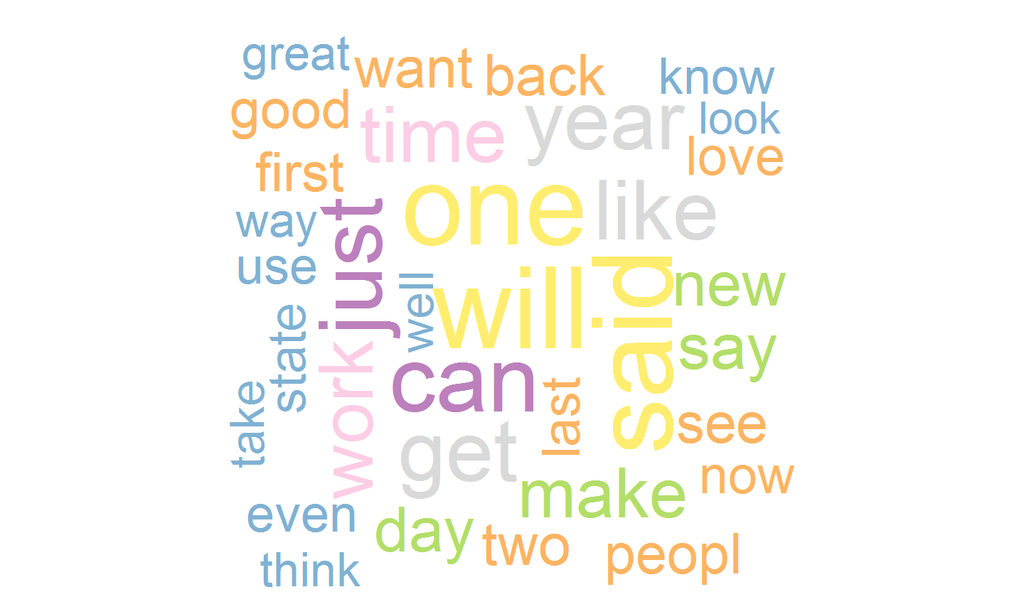